# InVivoStat Correlation Analysis

## Responses

This module assesses the correlation between the response variables Resp22 and Resp23.

## Non-categorised results

### Scatterplot of the observed data

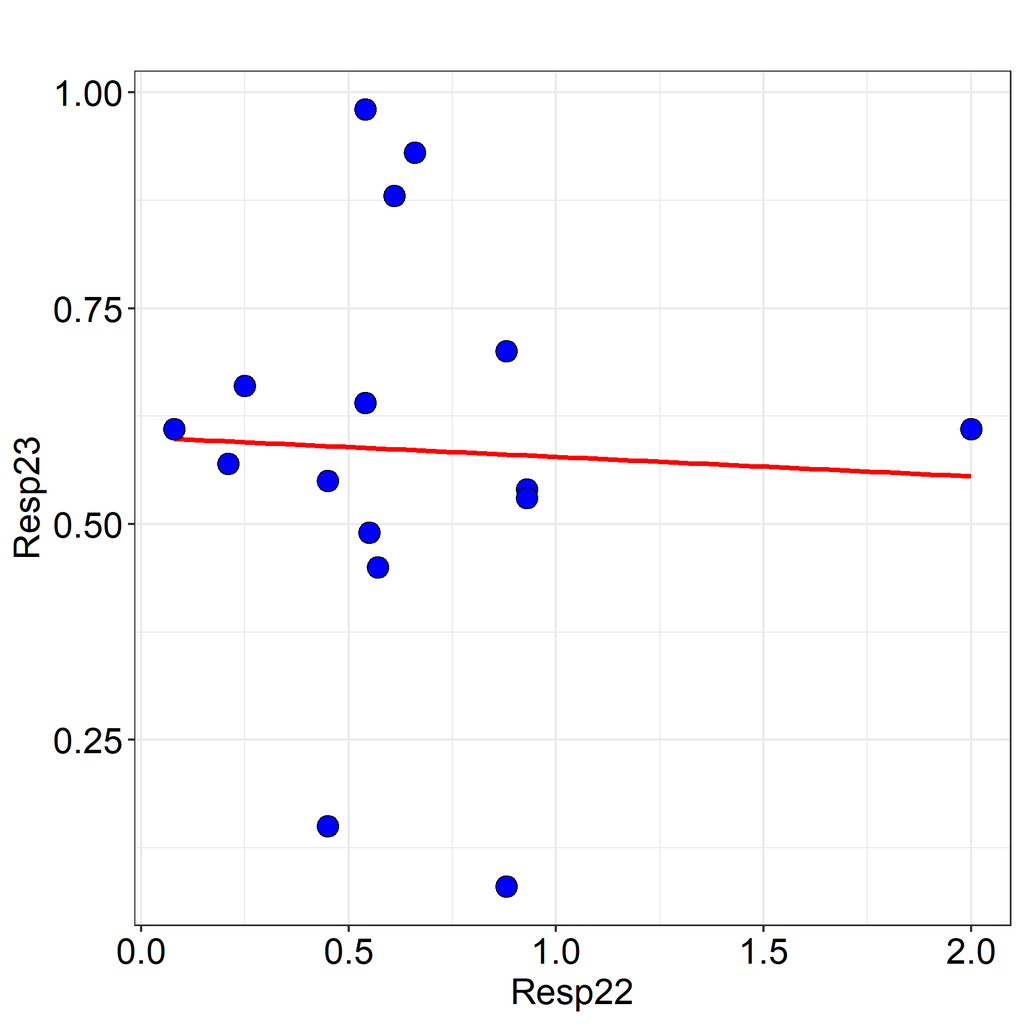

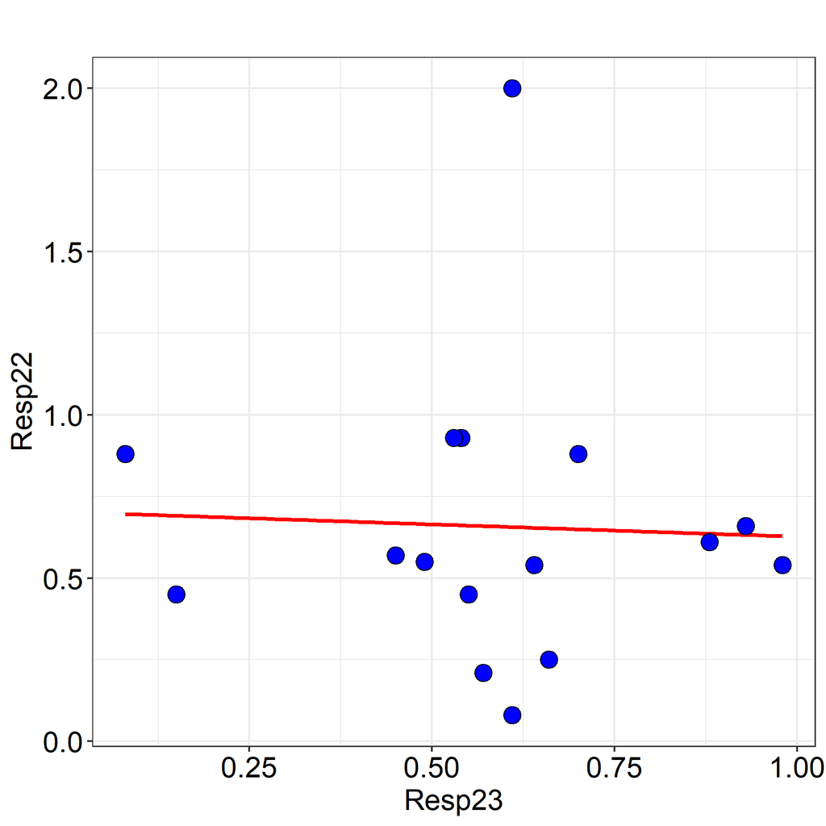

### Matrixplot, including linear regression lines

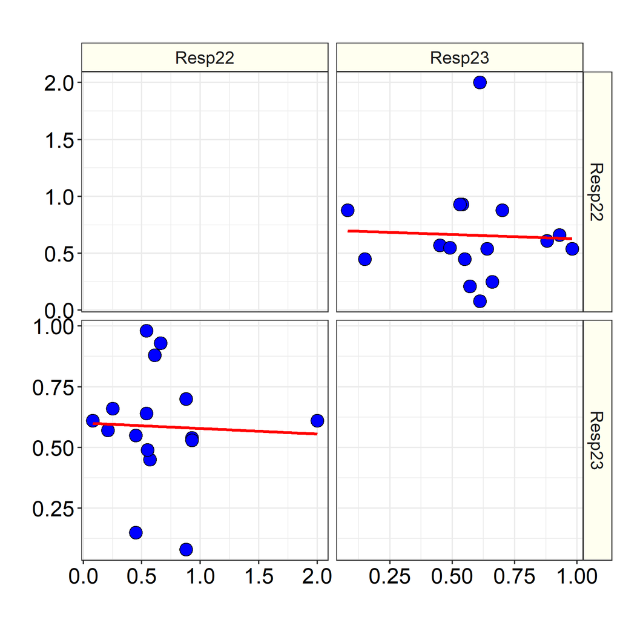

### Table of results for the one-sided (greater than) Pearson's product moment correlation coefficient

| Correlation | First variable |  | Second variable | n | Correlation Coefficient | Test statistic | p-value |
| --- | --- | --- | --- | --- | --- | --- | --- |
| 1 | Resp22 | vs. | Resp23 | 16 | -0.041 | -0.155 | 0.5604 |

### Matrix table of correlation coefficients

|  | Resp22 | Resp23 |
| --- | --- | --- |
| Resp22 | 1 | -0.041 |
| Resp23 | -0.041 | 1 |

### Matrix table of p-values

|  | Resp22 | Resp23 |
| --- | --- | --- |
| Resp22 |  | 0.5604 |
| Resp23 | 0.5604 |  |

### Matrix table of sample sizes

|  | Resp22 | Resp23 |
| --- | --- | --- |
| Resp22 |  | 16 |
| Resp23 | 16 |  |

Conclusion: The correlation is not statistically significant at the 1% level.

## Categorised results

### Categorised scatterplot of the observed data

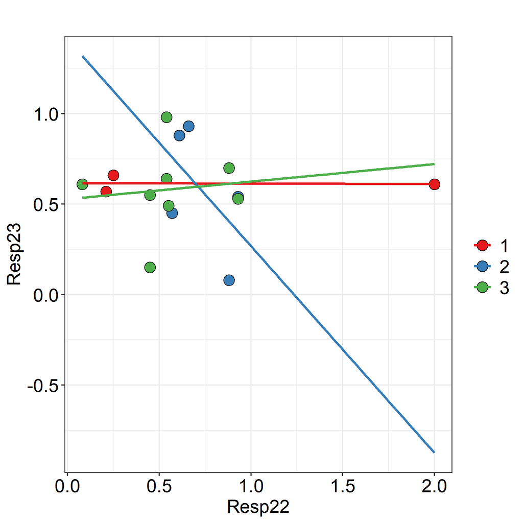

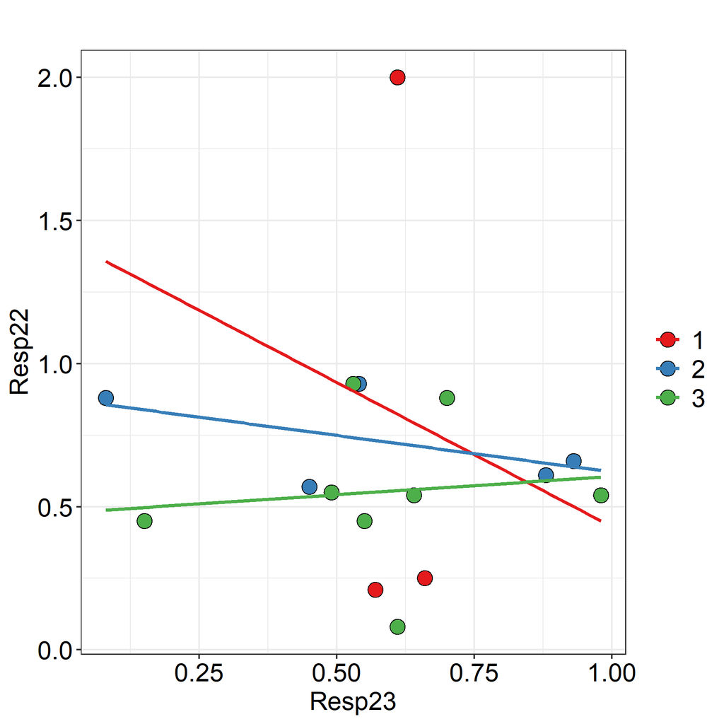

### Categorised matrixplot, including linear regression lines

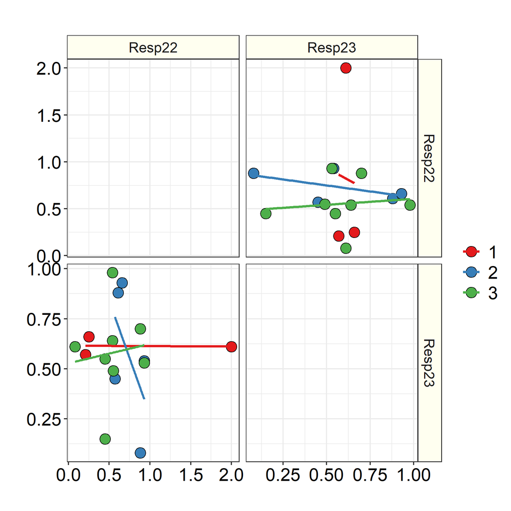

### Table of results for the one-sided (greater than) Pearson's product moment correlation coefficient

| Correlation | Categorisation factor | First variable |  | Second variable | n | Correlation Coefficient | Test statistic | p-value |
| --- | --- | --- | --- | --- | --- | --- | --- | --- |
| 1 | 1 | Resp22 | vs. | Resp23 | 3 | -0.044 | -0.045 | 0.5142 |
| 2 | 2 | Resp22 | vs. | Resp23 | 5 | -0.540 | -1.111 | 0.8262 |
| 3 | 3 | Resp22 | vs. | Resp23 | 8 | 0.111 | 0.274 | 0.3967 |

### Matrix table of correlation coefficients

| Categorisation factor |  | Resp22 | Resp23 |
| --- | --- | --- | --- |
| 1 | Resp22 | 1 | -0.044 |
| 1 | Resp23 | -0.044 | 1 |
| 2 | Resp22 | 1 | -0.540 |
| 2 | Resp23 | -0.540 | 1 |
| 3 | Resp22 | 1 | 0.111 |
| 3 | Resp23 | 0.111 | 1 |

### Matrix table of p-values

| Categorisation factor |  | Resp22 | Resp23 |
| --- | --- | --- | --- |
| 1 | Resp22 |  | 0.5142 |
| 1 | Resp23 | 0.5142 |  |
| 2 | Resp22 |  | 0.8262 |
| 2 | Resp23 | 0.8262 |  |
| 3 | Resp22 |  | 0.3967 |
| 3 | Resp23 | 0.3967 |  |

### Matrix table of sample sizes

| Categorisation factor |  | Resp22 | Resp23 |
| --- | --- | --- | --- |
| 1 | Resp22 |  | 3 |
| 1 | Resp23 | 3 |  |
| 2 | Resp22 |  | 5 |
| 2 | Resp23 | 5 |  |
| 3 | Resp22 |  | 8 |
| 3 | Resp23 | 8 |  |

Conclusion: There are no statistically significant correlations at the 1% level.

## Analysis description

The test statistic is based on Pearson's product moment correlation coefficient cor(x, y) and follows a t distribution with length(x)-2 degrees of freedom if the samples follow independent normal distributions, see Snedecor and Cochran (1989).

For more information on the theoretical approaches that are implemented within this module, see Bate and Clark (2014).

## References

When referring to InVivoStat, please cite 'InVivoStat, version 5.2.0'.

Bate, S.T. and Clark, R.A. (2014). The Design and Statistical Analysis of Animal Experiments. Cambridge University Press.

Snedecor, G.W. and Cochran, W.G. (1989). Statistical Methods. 8th edition; Iowa State University Press, Iowa, USA.